# ABLG47625 methylation analyses using all reference genome comined into one fasta file

charles-gumbi

2025-08-13

# The Ideal Scenario

In DNA methylation analysis, the goal is to differentiate between methylated and unmethylated cytosines. The process works by converting unmethylated cytosines to uracil (which is read as thymine during sequencing), while methylated cytosines remain unchanged. **Unmethylated Control (Unmethylated Lambda DNA):** This is a DNA sample with no methylated cytosines. After treatment, all unmethylated cytosines should be converted. The conversion efficiency is a measure of how successfully this process occurred. An ideal conversion efficiency would be 100%, but values of 99% or higher are considered excellent. A low conversion efficiency means some unmethylated cytosines weren’t converted, leading to an overestimation of methylation in your samples. **Methylated Control (CpG-methylated pUC19 DNA):** This is a DNA sample where all cytosines (specifically in a CpG context) have been methylated, typically using an enzyme. After bisulfite treatment, these methylated cytosines should not be converted. The methylation percentage of this control should be close to 100% (e.g., 95-98%). This percentage measures the stability of the methylated cytosines and the effectiveness of the bisulfite treatment in leaving them untouched. **Why They Aren’t Identical:**While the two values are related and both reflect the quality of the conversion, they are not direct mirrors of each other for several key reasons: **Enzymatic vs. Chemical Efficiency:** A methylated control is usually created with an enzyme, and enzymatic methylation is rarely 100% complete. For example, some commercially available methylated controls are stated to be 96-98% methylated. An unmethylated control, like lambda DNA, is naturally unmethylated, so it starts with a 0% methylation baseline. The conversion efficiency for the unmethylated control is a measure of the chemical reaction’s success, while the methylation percentage of the methylated control is a measure of both the chemical reaction and the initial enzymatic methylation. **Bisulfite Conversion Limitations:** The bisulfite conversion process itself is harsh and can cause some DNA degradation. This can also lead to a slight overestimation of methylation in the unmethylated control, even if conversion is very high. It’s common to see a very small methylation percentage (e.g., <1%) in an unmethylated control, which corresponds to a conversion efficiency of >99%. **Different Metrics, Same Goal:** In essence, the unmethylated control is used to measure the efficiency of conversion, while the methylated control is used to measure the stability of methylated sites during the conversion process. They are both essential quality control checks for the overall methylation analysis workflow. So, while a high methylation percentage in the methylated control and a high conversion efficiency in the unmethylated control are both indicators of a successful experiment, they are measuring slightly different aspects of the process and are not expected to be perfectly complementary (e.g., 98% methylation and 2% conversion inefficiency).

```r
# Load necessary R packages for data manipulation and visualization
library(dplyr)
```

```r
library(ggplot2)
library(readr)
library(hrbrthemes)
library(data.table)
library(tidyverse)
library(gcookbook)
library(extrafont)
library(hunspell)
```

# Modifications from last analyses

1. **Removed T4 and XP-12 phages from the reference alignment.** *NEB tech support advice:* “We include T4 and XP-12 phages in our control references for hydroxymethylation assessment (a related product). Since you did not spike T4 or XP-12 into your libraries, you can likely ignore any reads that happen to align to these contigs. If your fin samples do actually contain phages related to XP-12 and T4, you may see more coverage. If you’re interested in the phage genomics, I suggest that you supplement your genome with a more comprehensive database of phage contigs for more interpretable results. Since we’re effectively working with only three bases in converted libraries, it’s important that the reference sequences represent all the abundant sources of input DNA. If not, you may see anomalous coverage where the aligner misplaces reads derived from other sources on your expected reference. There’s always a risk of this in complex samples, which is why I think it’s good to be suspicious of methylation calls in regions of unusually high coverage.”
2. **Reran the pipeline using a combined reference sequence (pop + pop mitochondrial genome + phage lambda + plasmid puc19c) instead of running the pipeline with each sequence as a separate reference.** *NEB tech advice:* “It sounds like you’re running with just one genome at a time. I don’t recommend that, especially not with converted libraries, due to the potential for mis-mapping and confused methylation calls. Maybe it’s worth another try with the complete genome, including chrM and the control genomes.”
3. **Estimated conversion efficiency using chrM and phage lambda, both of which can be used as negative controls (unmethylated).** *NEB tech advice:* “You can get an estimate of APOBEC activity by looking at chrM, which is unmethylated in eukaryotes I know of. Unfortunately, there is not really a built-in TET2+BGT/methylated control (you can get an approximation if you know of some imprinted region).”

### **Data Loading and Preparation**

```r
# A function to read a single large file, calculate summaries, and free up memory.
process_methylation_file <- function(file_path, context_name) {
  # Read the bedGraph file using fread, which is very efficient for large files
  data <- fread(file_path, header = FALSE, col.names = c("chrom", "start", "end", "percent_methylation", "methylated_reads", "unmethylated_reads"))

  # Add the context column and remove missing values
  data$context <- context_name
  data <- na.omit(data)

  # Group by chromosome and context to calculate summary statistics
  summary_stats <- data %>%
    group_by(chrom, context) %>%
    summarise(
      total_reads = sum(methylated_reads + unmethylated_reads),
      mean_meth = mean(percent_methylation, na.rm = TRUE),
      median_meth = median(percent_methylation, na.rm = TRUE),
      sd_meth = sd(percent_methylation, na.rm = TRUE),
      .groups = "drop"
    )

  # Explicitly remove the large raw data from memory and run garbage collection
  rm(data)
  gc()

  return(summary_stats)
}

# Process each file sequentially
cpg_summary <- process_methylation_file("/home/cgumbi/methylation/refcombined/ABLG-47625_CpG.bedGraph", "CpG")
chg_summary <- process_methylation_file("/home/cgumbi/methylation/refcombined/ABLG-47625_CHG.bedGraph", "CHG")
chh_summary <- process_methylation_file("/home/cgumbi/methylation/refcombined/ABLG-47625_CHH.bedGraph", "CHH")

# Combine the much smaller summary data frames
all_summary <- bind_rows(cpg_summary, chg_summary, chh_summary)

# Write the combined summary data to a CSV file
write.csv(all_summary, "~/methylation/Methyl47625/tables/summary_all_contexts.csv", row.names = FALSE)
```

#### **Plotting and Analysis on Summarized Data**

```r
# Plot the methylation levels across contexts using the summary data
all_context_plot <- ggplot(all_summary, aes(x = context, y = mean_meth, fill = context)) +
  geom_boxplot(outlier.alpha = 0.3, outlier.size = 0.5) +
  labs(title = "Mean Methylation Across Contexts", x = "Context", y = "Mean Methylation (%)") +
  theme_ipsum() +
  theme(legend.position = "none", axis.text.x = element_text(angle = 45, hjust = 1))

# Save the plot
ggsave("~/methylation/Methyl47625/figures/all_context_methylation_plot.png", plot = all_context_plot, width = 10, height = 6, dpi = 300)

# Note: The original `contextvschrom` plot relied on raw data. You can recreate a similar
# bar plot using the summarized data if that's sufficient.
contextvschrom <- all_summary %>%
  filter(chrom %in% c("OR482510.1", "plasmid_puc19c", "phage_lambda")) %>%
  ggplot(aes(x = context, y = mean_meth, fill = chrom)) +
  geom_bar(stat = "identity", position = "dodge") +
  labs(title = "Mean methylation per context by chromosome", x = "Context", y = "Methylation", fill = "Chrom") +
  theme_ipsum()
ggsave("~/methylation/Methyl47625/figures/contextvschrom_plot.png", plot = contextvschrom, width = 10, height = 6, dpi = 300)
```

#### **Making scatter and Methylation Bias Plots**

Plots that require plotting every single read, such as the scatter plots and methylation bias plots (`pUC19_scatter`, `lambda_scatter`, `chrM_scatter`, etc.), are still memory-intensive. For these, the best practice is to load *one file at a time*, generate the plot, save it, and then clear the data from memory immediately. This ensures that you never have multiple large datasets in memory at once.

```r
# Function to read, plot, and clean up for a single chromosome
plot_single_chromosome <- function(file_path, chrom_name, title, subtitle, x_label, y_label) {
  # Read the specific chromosome data from the large file
  data <- fread(file_path, header = FALSE, col.names = c("chrom", "start", "end", "percent_methylation", "methylated_reads", "unmethylated_reads"))

  # Clean up and filter the data for the target chromosome
  data <- na.omit(data)
  data$chrom <- gsub("genome_hic_", "", data$chrom)
  data$chrom <- gsub("_RagTag", "", data$chrom)
  data_subset <- data %>% filter(chrom == chrom_name)

  # Create the plot
  plot <- ggplot(data_subset, aes(x = start, y = percent_methylation)) +
    geom_point(alpha = 0.6, size = 2) +
    labs(title = title, subtitle = subtitle, x = x_label, y = y_label) +
    theme_ipsum()

  # Save the plot
  ggsave(paste0("~/methylation/Methyl47625/figures/", gsub(" ", "_", title), ".png"), plot = plot, width = 10, height = 6, dpi = 300)

  # Clean up and free memory
  rm(data, data_subset)
  gc()
}
# Example usage for the scatter plots
plot_single_chromosome("/home/cgumbi/methylation/refcombined/ABLG-47625_CpG.bedGraph", "plasmid_puc19c", "Plasmid pUC19 Scatter", "Control DNA CpG methylated pUC19", "Read position", "Percentage methylation (%)")
```

```
##           used (Mb) gc trigger   (Mb)  max used   (Mb)
## Ncells 1280873 68.5    2134771  114.1   2134771  114.1
## Vcells 2284519 17.5  618100116 4715.8 965174313 7363.7
```

```r
plot_single_chromosome("/home/cgumbi/methylation/refcombined/ABLG-47625_CpG.bedGraph", "phage_lambda", "Lambda Scatter", "Control DNA unmethylated lambda", "Read position", "Percentage methylation (%)")
```

```
##           used (Mb) gc trigger   (Mb)  max used   (Mb)
## Ncells 1281182 68.5    2134771  114.1   2134771  114.1
## Vcells 2292766 17.5  494480093 3772.6 965174313 7363.7
```

```r
plot_single_chromosome("/home/cgumbi/methylation/refcombined/ABLG-47625_CpG.bedGraph", "OR482510.1", "CpG methylation on chrM", NULL, "Read position", "Percentage methylation (%)")
```

```
##           used (Mb) gc trigger   (Mb)  max used   (Mb)
## Ncells 1281194 68.5    2134771  114.1   2134771  114.1
## Vcells 2286915 17.5  395584075 3018.1 965174313 7363.7
```

### Conversion Efficiency Calculation

The frequency of CpG methylation in the λ-bacteriophage genome provides an estimate of the conversion efficiency. This is because the λ-bacteriophage genome is grown in methylase-negative *Escherichia coli*, which cannot methylate cytosines in a CpG context. For example, if the observed CpG methylation frequency in the λ-bacteriophage is 0.2%, the cytosine-to-thymine conversion in the sample is estimated to be 99.8% efficient.

*(Singer 2019: “A practical guide to the Measurement and analyses of DNA methylation”)*

*NEB Tech advice on using CHH and CHG methylation to supplement controls and chrM for testing conversion efficiency:* “If I wanted to judge the conversion efficiency, I would simply look at the lowest methylation you see anywhere. Often it is enough to just look at the methylation levels in a non-CG context (in mammalian systems); otherwise, some people look at reads from the MT, or within CpG islands. If you see a general methylation of 0.3% in a non-CG context, then your conversion efficiency must have been at least 99.7%.”

```r
# --- Calculate Conversion Efficiency from CpG controls ---

# We will load the CpG file specifically for this calculation and then clear it.
cpg_data_for_eff <- fread("/home/cgumbi/methylation/refcombined/ABLG-47625_CpG.bedGraph", header = FALSE, col.names = c("chrom", "start", "end", "percent_methylation", "methylated_reads", "unmethylated_reads"))

# Clean the chromosome names and subset for controls
cpg_data_for_eff$chrom <- gsub("genome_hic_", "", cpg_data_for_eff$chrom)
cpg_data_for_eff$chrom <- gsub("_RagTag", "", cpg_data_for_eff$chrom)

phage_lambda <- cpg_data_for_eff %>% filter(chrom == "phage_lambda")
phage_lambda[, total_reads := methylated_reads + unmethylated_reads]
# Mito genome CpG methylation extraction
chrM <- cpg_data_for_eff %>% filter(chrom == "OR482510.1")
chrM[, total_reads := methylated_reads + unmethylated_reads]
#average methylation on chrM
chrM_df <- chrM %>%
   group_by(chrom) %>%
   summarize(
     avg_methylation = mean(percent_methylation, na.rm = TRUE),
     total_methylated_reads = sum(methylated_reads, na.rm = TRUE),
     total_unmethylated_reads = sum(unmethylated_reads, na.rm = TRUE),
     .groups = "drop")

write.csv(chrM_df,"~/methylation/Methyl47625/tables/Mito_summarized_data.csv", row.names = F)

#average methylation on chrM
phage_lambda_df <- phage_lambda %>%
   group_by(chrom) %>%
   summarize(
     avg_methylation = mean(percent_methylation, na.rm = TRUE),
     total_methylated_reads = sum(methylated_reads, na.rm = TRUE),
     total_unmethylated_reads = sum(unmethylated_reads, na.rm = TRUE),
     .groups = "drop")

write.csv(chrM_df,"~/methylation/Methyl47625/tables/Lamda_summarized_data.csv", row.names = F)

# Calculate efficiency for lambda
conv_eff_lambda <- 100 - mean(phage_lambda$percent_methylation, na.rm = TRUE)
cat("APOBEC Conversion efficiency from phage Lambda:", round(conv_eff_lambda, 2), "%\n")
```

```
## APOBEC Conversion efficiency from phage Lambda: 96.55 %
```

```r
# Calculate efficiency for chrM
conv_eff_chrM <- 100 - mean(chrM$percent_methylation, na.rm = TRUE)
cat("APOBEC Conversion efficiency from chrM:", round(conv_eff_chrM, 2), "%\n")
```

```
## APOBEC Conversion efficiency from chrM: 96.91 %
```

```r
# Free up memory
#@rm(cpg_data_for_eff, phage_lambda, chrM)
#gc()

# --- Calculate Conversion Efficiency from non-CpG contexts ---
# These calculations also require a memory-efficient approach.

# Load and process CHG data for efficiency calculation
chg_data_for_eff <- fread("/home/cgumbi/methylation/refcombined/ABLG-47625_CHG.bedGraph", header = FALSE, col.names = c("chrom", "start", "end", "percent_methylation", "methylated_reads", "unmethylated_reads"))
conv_eff_chg <- 100 - mean(chg_data_for_eff$percent_methylation, na.rm = TRUE)
cat("APOBEC Conversion efficiency from CHG:", round(conv_eff_chg, 2), "%\n")
```

```
## APOBEC Conversion efficiency from CHG: 96.24 %
```

```r
rm(chg_data_for_eff)
gc()
```

```
##            used  (Mb) gc trigger   (Mb)  max used   (Mb)
## Ncells  1304640  69.7    2134771  114.1   2134771  114.1
## Vcells 46971599 358.4  316467260 2414.5 965174313 7363.7
```

```r
# Load and process CHH data for efficiency calculation
chh_data_for_eff <- fread("/home/cgumbi/methylation/refcombined/ABLG-47625_CHH.bedGraph", header = FALSE, col.names = c("chrom", "start", "end", "percent_methylation", "methylated_reads", "unmethylated_reads"))
conv_eff_chh <- 100 - mean(chh_data_for_eff$percent_methylation, na.rm = TRUE)
cat("APOBEC Conversion efficiency from CHH:", round(conv_eff_chh, 2), "%\n")
```

```
## APOBEC Conversion efficiency from CHH: 96.38 %
```

```r
rm(chh_data_for_eff)
gc()
```

```
##            used  (Mb) gc trigger   (Mb)  max used   (Mb)
## Ncells  1304673  69.7    2134771  114.1   2134771  114.1
## Vcells 46971650 358.4  419296424 3199.0 965174313 7363.7
```

```r
# --- Create and Plot Summary Table ---
con_eff <- data.frame(
  approach = c("chrM","Lambda", "CHG methylation", "CHH methylation"),
  conversion_efficiency = c(conv_eff_chrM, conv_eff_lambda, conv_eff_chg, conv_eff_chh))

con_eff_plot <- ggplot(con_eff, aes(x = approach, y = conversion_efficiency, fill = approach)) +
  geom_bar(stat = "identity", position = "dodge", width = 0.6) +
  labs(
    title = "APOBEC Conversion efficiency",
    subtitle = paste0("CHG = ", round(conv_eff_chg, 2), "%, CHH = ", round(conv_eff_chh, 2), "%, chrM = ", round(conv_eff_chrM, 2), "%, Lambda = ", round(conv_eff_lambda, 2), "%"),
    x = "Approach",
    y = "Conversion efficiency (%)"
  ) +
  theme_ipsum() +
  theme(legend.position = "none", axis.text.x = element_text(angle = 45, hjust = 1))

ggsave("~/methylation/Methyl47625/figures/APOBEC_conversion_efficency_plot.png", plot = con_eff_plot, width = 10, height = 6, dpi = 300)
write.csv(con_eff,"~/methylation/Methyl47625/tables/APOBEC_conversion_efficiency.csv", row.names= TRUE)
```

# Extracting and saving data for control

This code snippet processes each large bedGraph file sequentially to avoid memory issues. It identifies the control chromosomes (“OR482510.1”, “plasmid_puc19c”, and “phage_lambda”) and writes the data for each one into a separate, dedicated CSV file.

```r
# Define the file paths for the three large bedGraph files
file_paths <- c(
  "/home/cgumbi/methylation/refcombined/ABLG-47625_CpG.bedGraph",
  "/home/cgumbi/methylation/refcombined/ABLG-47625_CHG.bedGraph",
  "/home/cgumbi/methylation/refcombined/ABLG-47625_CHH.bedGraph"
)

# A list of the chromosomes we want to subset
chromosomes_to_subset <- c("OR482510.1", "plasmid_puc19c", "phage_lambda")

# Loop through each large bedGraph file
for (file_path in file_paths) {
  # Determine the context (CpG, CHG, or CHH) from the file name
  context <- sub(".bedGraph", "", basename(file_path))
  context <- sub("ABLG-47625_", "", context)
  cat(paste0("Processing ", context, " data...\n"))

  # Read the large file using fread for maximum efficiency
  raw_data <- fread(file_path, header = FALSE,
                      col.names = c("chrom", "start", "end", "percent_methylation", "methylated_reads", "unmethylated_reads"))

  # Clean up chromosome names if this is the CpG file (based on previous scripts)
  if (context == "CpG") {
    raw_data$chrom <- gsub("genome_hic_", "", raw_data$chrom)
    raw_data$chrom <- gsub("_RagTag", "", raw_data$chrom)
  }

  # Filter the raw data to only keep the chromosomes of interest
  subset_data <- raw_data %>% filter(chrom %in% chromosomes_to_subset)

  # Check if any data was found
  if (nrow(subset_data) == 0) {
    cat("No data found for control chromosomes in", context, "file.\n")
    # Clean up and continue to the next file
    rm(raw_data, subset_data)
    gc()
    next
  }

  # Split the subsetted data into separate data frames based on chromosome name
  split_by_chrom <- split(subset_data, subset_data$chrom)

  # Loop through the split data frames and save each one to a CSV
  for (chrom_name in names(split_by_chrom)) {
    df_to_save <- split_by_chrom[[chrom_name]]

    # Create a clean file name
    file_name <- paste0(context, "_", chrom_name, ".csv")
    full_path <- file.path("~/methylation/Methyl47625/tables/", file_name)

    # Write the data frame to the specified CSV file
    write.csv(df_to_save, full_path, row.names = FALSE)
    cat(paste0("Saved data for ", chrom_name, " (", context, ") to ", full_path, "\n"))
  }

  # Explicitly remove the large raw data and the subsetted data to free up memory
  rm(raw_data, subset_data, split_by_chrom)
  gc()
}
```

```
## Processing CpG data...
## Saved data for OR482510.1 (CpG) to ~/methylation/Methyl47625/tables//CpG_OR482510.1.csv
## Saved data for phage_lambda (CpG) to ~/methylation/Methyl47625/tables//CpG_phage_lambda.csv
## Saved data for plasmid_puc19c (CpG) to ~/methylation/Methyl47625/tables//CpG_plasmid_puc19c.csv
## Processing CHG data...
## Saved data for OR482510.1 (CHG) to ~/methylation/Methyl47625/tables//CHG_OR482510.1.csv
## Saved data for phage_lambda (CHG) to ~/methylation/Methyl47625/tables//CHG_phage_lambda.csv
## Saved data for plasmid_puc19c (CHG) to ~/methylation/Methyl47625/tables//CHG_plasmid_puc19c.csv
## Processing CHH data...
## Saved data for OR482510.1 (CHH) to ~/methylation/Methyl47625/tables//CHH_OR482510.1.csv
## Saved data for phage_lambda (CHH) to ~/methylation/Methyl47625/tables//CHH_phage_lambda.csv
## Saved data for plasmid_puc19c (CHH) to ~/methylation/Methyl47625/tables//CHH_plasmid_puc19c.csv
```

```r
cat("\nProcessing complete. All control data has been extracted and saved.\n")
```

```
##
## Processing complete. All control data has been extracted and saved.
```

# Cytosine report

```r
library(data.table)
# Path to the file
file_path <- "~/methylation/refcombined/Lambda_genome.cytosine_report.txt"
#--cytosine_report  A per-base exhaustive report comparable to that produced
#                  with the same option in Bismark's methylation extractor. The
#                  output is a tab-separated file with the following columns:
#                  chromosome, position (1-based), strand, number of alignments
#                  supporting methylation, number of alignments supporting
#                  unmethylation, CG/CHG/CHH, trinucleotide context. This is not
#                  compatible with --fraction, --counts, --methylKit, or
#                  --mergeContext. The produces a single file with a
#                  .cytosine_report.txt extension. Note that even bases with no
#                  coverage will be included in the output.
# Defining column names based on MethylDackel documentation
col_names <- c("CHROM", "POS", "STRAND", "METHYLATED",
               "UNMETHYLATED", "CONTEXT", "TRINUCLEOTIDE")  # adjust if your file has only 6 columns
# Read the file
lambda_cytosine_report <- fread(file_path, sep = "\t", header = FALSE, col.names = col_names, data.table = FALSE)
# Filter out rows where CHROM contains "genome_hic_scaffold_"
#cytosine_report <- cytosine_report[!grepl("genome_hic_scaffold_", cytosine_report$CHROM), ]
#cytosine_report <- cytosine_report[!grepl("ptg000", cytosine_report$CHROM), ]
#write.csv(puc19_cytosine_report,"~/methylation/Methyl47625/tables/Lambda_genome_cytosine_report.csv", row.names= TRUE)
```

# Read counts

```r
library(data.table)
read_and_subset_large_csv <- function(file_path) {
  # Efficiently read only the needed columns first
  dt <- fread(file_path)

  # Subset for each chrom of interest
  or482510_data <- dt[chrom == "OR482510.1"]
  plasmid_puc19c_data <- dt[chrom == "plasmid_puc19c"]
  phage_lambda_data <- dt[chrom == "phage_lambda"]

  # Free the main dt to save memory
  rm(dt)
  gc()

  # Return a list with three data.tables
  return(list(
    OR482510.1 = or482510_data,
    plasmid_puc19c = plasmid_puc19c_data,
    phage_lambda = phage_lambda_data
  ))
}
result <- read_and_subset_large_csv("~/methylation/refcombined/Methylation_all_context.csv")

# lambda all read count report
or_df <- result$OR482510.1
or_df[, total_reads := methylated_reads + unmethylated_reads]
# lambda all read count report
plasmid_df <- result$plasmid_puc19c
plasmid_df[, total_reads := methylated_reads + unmethylated_reads]
# lambda all read count report
phage_df <- result$phage_lambda
phage_df[, total_reads := methylated_reads + unmethylated_reads]
# save
write.csv(or_df,"~/methylation/Methyl47625/tables/Mito_genome_reads_counts.csv", row.names= TRUE)
write.csv(plasmid_df,"~/methylation/Methyl47625/tables/Puc19c_genome_reads_counts.csv", row.names= TRUE)
write.csv(phage_df,"~/methylation/Methyl47625/tables/Lambda_genome_reads_counts.csv", row.names= TRUE)
# print
or_df
```

| chrom | start | end | percent_methylation | methylated_reads | unmethylated_reads | context | total_reads |
| --- | --- | --- | --- | --- | --- | --- | --- |
| OR482510.1 | 1987 | 1988 | 0 | 0 | 1 | CpG | 1 |
| OR482510.1 | 2006 | 2007 | 0 | 0 | 1 | CpG | 1 |
| OR482510.1 | 2026 | 2027 | 0 | 0 | 1 | CpG | 1 |
| OR482510.1 | 2058 | 2059 | 0 | 0 | 1 | CpG | 1 |
| OR482510.1 | 2084 | 2085 | 0 | 0 | 1 | CpG | 1 |
| OR482510.1 | 2088 | 2089 | 0 | 0 | 1 | CpG | 1 |
| OR482510.1 | 2090 | 2091 | 0 | 0 | 1 | CpG | 1 |
| OR482510.1 | 2160 | 2161 | 0 | 0 | 2 | CpG | 2 |
| OR482510.1 | 2207 | 2208 | 0 | 0 | 3 | CpG | 3 |
| OR482510.1 | 2217 | 2218 | 0 | 0 | 3 | CpG | 3 |

[output cut: 607 more lines]

```r
phage_df
```

| chrom | start | end | percent_methylation | methylated_reads | unmethylated_reads | context | total_reads |
| --- | --- | --- | --- | --- | --- | --- | --- |
| phage_lambda | 134 | 135 | 0 | 0 | 1 | CpG | 1 |
| phage_lambda | 154 | 155 | 0 | 0 | 1 | CpG | 1 |
| phage_lambda | 155 | 156 | 100 | 1 | 0 | CpG | 1 |
| phage_lambda | 177 | 178 | 0 | 0 | 1 | CpG | 1 |
| phage_lambda | 178 | 179 | 0 | 0 | 1 | CpG | 1 |
| phage_lambda | 225 | 226 | 0 | 0 | 1 | CpG | 1 |
| phage_lambda | 226 | 227 | 0 | 0 | 1 | CpG | 1 |
| phage_lambda | 230 | 231 | 0 | 0 | 1 | CpG | 1 |
| phage_lambda | 231 | 232 | 0 | 0 | 1 | CpG | 1 |
| phage_lambda | 238 | 239 | 0 | 0 | 1 | CpG | 1 |

[output cut: 6917 more lines]

```r
plasmid_df
```

| chrom | start | end | percent_methylation | methylated_reads | unmethylated_reads | context | total_reads |
| --- | --- | --- | --- | --- | --- | --- | --- |
| plasmid_puc19c | 276 | 277 | 100 | 1 | 0 | CpG | 1 |
| plasmid_puc19c | 279 | 280 | 100 | 1 | 0 | CpG | 1 |
| plasmid_puc19c | 280 | 281 | 100 | 1 | 0 | CpG | 1 |
| plasmid_puc19c | 284 | 285 | 100 | 1 | 0 | CpG | 1 |
| plasmid_puc19c | 285 | 286 | 100 | 1 | 0 | CpG | 1 |
| plasmid_puc19c | 294 | 295 | 100 | 1 | 0 | CpG | 1 |
| plasmid_puc19c | 295 | 296 | 100 | 1 | 0 | CpG | 1 |
| plasmid_puc19c | 302 | 303 | 100 | 1 | 0 | CpG | 1 |
| plasmid_puc19c | 303 | 304 | 100 | 1 | 0 | CpG | 1 |
| plasmid_puc19c | 312 | 313 | 100 | 1 | 0 | CpG | 1 |

[output cut: 731 more lines]

# Data summary

```r
# Group the data by the 'context' column and then summarize,
# calculating only the sum of 'methylated_reads'.
puc19_summarized_data <- plasmid_df %>%
  group_by(context) %>%
  summarise(
    total_reads = sum(total_reads, na.rm = TRUE),
    )

# Print the resulting summarized data frame.
print(puc19_summarized_data)
```

```
## # A tibble: 3 × 2
##   context total_reads
##   <chr>         <int>
## 1 CHG             210
## 2 CHH             515
## 3 CpG             240
```

```r
# You can also write the output to a new CSV file.
write.csv(puc19_summarized_data, "~/methylation/Methyl47625/tables/puc19_methylation_summary.csv", row.names = FALSE)
```

# Per base coverage analysis

In methylation analyses per base coverage is the same as “read depth”: how many reads cover a single base. Sometimes people say “coverage at this CpG” = 20×.

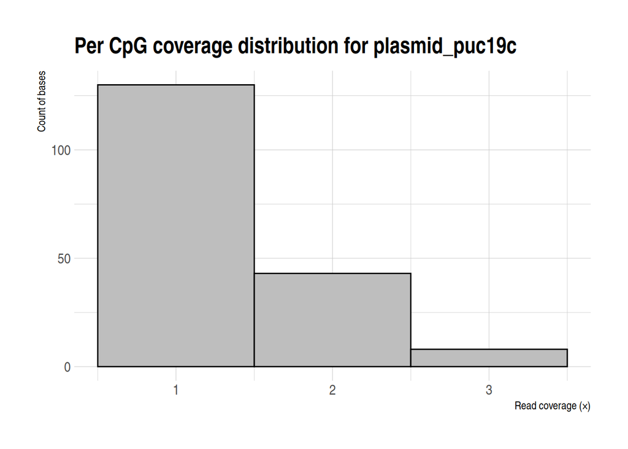

```r
# Load required packages
library(ggplot2)
library(data.table)   # fast reading for large files
# puc19 methylated control
puc19_covarage <- fread("~/methylation/Methyl47625/tables/CpG_plasmid_puc19c.txt")
ggplot(puc19_covarage, aes(x = per_base_coverage)) +
  geom_histogram(binwidth = 1, fill = "grey", color = "black") +
  labs(title = paste("Per CpG coverage distribution for", unique(puc19_covarage$chrom)),
       x = "Read coverage (×)", y = "Count of bases") +
  theme_ipsum()
```

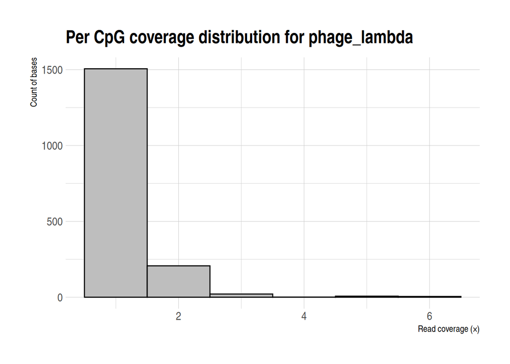

```r
# lambda unmethylated control
lambda_covarage <- fread("~/methylation/Methyl47625/tables/CpG_phage_lambda.txt")
ggplot(lambda_covarage, aes(x = per_base_coverage)) +
  geom_histogram(binwidth = 1, fill = "grey", color = "black") +
  labs(title = paste("Per CpG coverage distribution for", unique(lambda_covarage$chrom)),
       x = "Read coverage (×)", y = "Count of bases") +
  theme_ipsum()
```

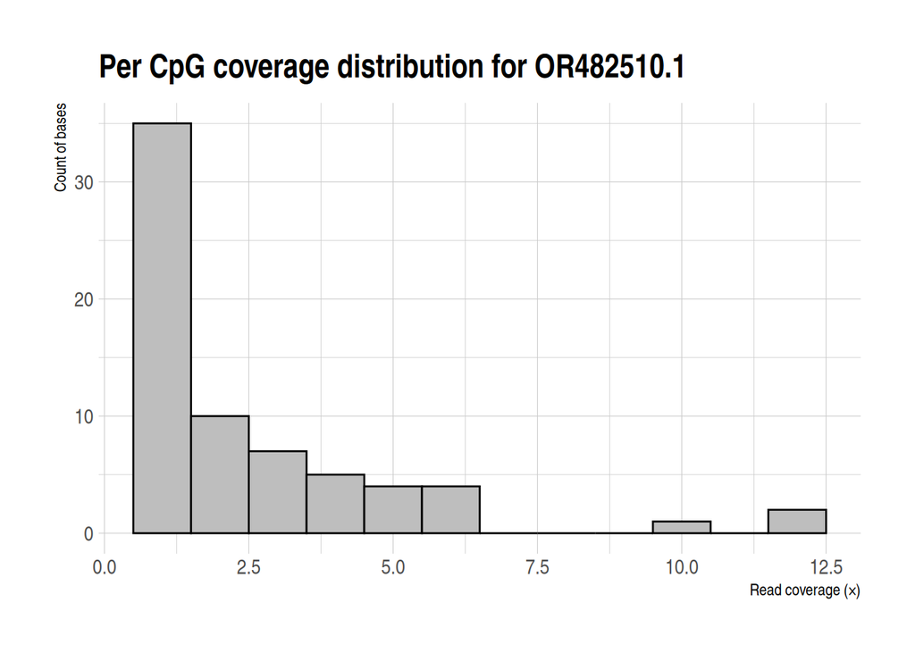

```r
# lambda unmethylated control
mito_covarage <- fread("~/methylation/Methyl47625/tables/CpG_OR482510.1.txt")
ggplot(mito_covarage, aes(x = per_base_coverage)) +
  geom_histogram(binwidth = 1, fill = "grey", color = "black") +
  labs(title = paste("Per CpG coverage distribution for", unique(mito_covarage$chrom)),
       x = "Read coverage (×)", y = "Count of bases") +
  theme_ipsum()
```

```r
puc19_covarage
```

| chrom | start | end | percent_methylation | methylated_reads | unmethylated_reads | read_depth | per_base_coverage |
| --- | --- | --- | --- | --- | --- | --- | --- |
| plasmid_puc19c | 276 | 277 | 100 | 1 | 0 | 1 | 1 |
| plasmid_puc19c | 279 | 280 | 100 | 1 | 0 | 1 | 1 |
| plasmid_puc19c | 280 | 281 | 100 | 1 | 0 | 1 | 1 |
| plasmid_puc19c | 284 | 285 | 100 | 1 | 0 | 1 | 1 |
| plasmid_puc19c | 285 | 286 | 100 | 1 | 0 | 1 | 1 |
| plasmid_puc19c | 294 | 295 | 100 | 1 | 0 | 1 | 1 |
| plasmid_puc19c | 295 | 296 | 100 | 1 | 0 | 1 | 1 |
| plasmid_puc19c | 302 | 303 | 100 | 1 | 0 | 1 | 1 |
| plasmid_puc19c | 303 | 304 | 100 | 1 | 0 | 1 | 1 |
| plasmid_puc19c | 312 | 313 | 100 | 1 | 0 | 1 | 1 |

[output cut: 171 more lines]

```r
lambda_covarage
```

| chrom | start | end | percent_methylation | methylated_reads | unmethylated_reads | read_depth | per_base_coverage |
| --- | --- | --- | --- | --- | --- | --- | --- |
| phage_lambda | 134 | 135 | 0 | 0 | 1 | 1 | 1 |
| phage_lambda | 154 | 155 | 0 | 0 | 1 | 1 | 1 |
| phage_lambda | 155 | 156 | 100 | 1 | 0 | 1 | 1 |
| phage_lambda | 177 | 178 | 0 | 0 | 1 | 1 | 1 |
| phage_lambda | 178 | 179 | 0 | 0 | 1 | 1 | 1 |
| phage_lambda | 225 | 226 | 0 | 0 | 1 | 1 | 1 |
| phage_lambda | 226 | 227 | 0 | 0 | 1 | 1 | 1 |
| phage_lambda | 230 | 231 | 0 | 0 | 1 | 1 | 1 |
| phage_lambda | 231 | 232 | 0 | 0 | 1 | 1 | 1 |
| phage_lambda | 238 | 239 | 0 | 0 | 1 | 1 | 1 |

[output cut: 1737 more lines]

```r
mito_covarage
```

| chrom | start | end | percent_methylation | methylated_reads | unmethylated_reads | read_depth | per_base_coverage |
| --- | --- | --- | --- | --- | --- | --- | --- |
| OR482510.1 | 1987 | 1988 | 0 | 0 | 1 | 1 | 1 |
| OR482510.1 | 2006 | 2007 | 0 | 0 | 1 | 1 | 1 |
| OR482510.1 | 2026 | 2027 | 0 | 0 | 1 | 1 | 1 |
| OR482510.1 | 2058 | 2059 | 0 | 0 | 1 | 1 | 1 |
| OR482510.1 | 2084 | 2085 | 0 | 0 | 1 | 1 | 1 |
| OR482510.1 | 2088 | 2089 | 0 | 0 | 1 | 1 | 1 |
| OR482510.1 | 2090 | 2091 | 0 | 0 | 1 | 1 | 1 |
| OR482510.1 | 2160 | 2161 | 0 | 0 | 2 | 2 | 2 |
| OR482510.1 | 2207 | 2208 | 0 | 0 | 3 | 3 | 3 |
| OR482510.1 | 2217 | 2218 | 0 | 0 | 3 | 3 | 3 |

[output cut: 58 more lines]

# Computing avarage depth and per base coverage

```r
# Compute averages
puc19_summary_table <- puc19_covarage %>%
  summarise(
    average_percent_methylation = mean(percent_methylation, na.rm = TRUE),
    average_read_depth = mean(read_depth, na.rm = TRUE),
    average_per_base_coverage = mean(per_base_coverage, na.rm = TRUE))
# Compute averages
lambda_summary_table <- lambda_covarage %>%
  summarise(
    average_percent_methylation = mean(percent_methylation, na.rm = TRUE),
    average_read_depth = mean(read_depth, na.rm = TRUE),
    average_per_base_coverage = mean(per_base_coverage, na.rm = TRUE))
# Compute averages
mito_summary_table <- mito_covarage %>%
  summarise(
    average_percent_methylation = mean(percent_methylation, na.rm = TRUE),
    average_read_depth = mean(read_depth, na.rm = TRUE),
    average_per_base_coverage = mean(per_base_coverage, na.rm = TRUE))

# Save the summary table as a text file (tab-separated)
write_tsv(lambda_summary_table, "~/methylation/Methyl47625/tables/lambda_coverage_summary_table.txt")
write_tsv(puc19_summary_table, "~/methylation/Methyl47625/tables/puc19_coverage_summary_table.txt")
write_tsv(mito_summary_table, "~/methylation/Methyl47625/tables/mito_coverage_summary_table.txt")
#print tables
puc19_summary_table
```

| average_percent_methylation | average_read_depth | average_per_base_coverage |
| --- | --- | --- |
| 96.68508 | 1.325967 | 1.325967 |

```r
lambda_summary_table
```

| average_percent_methylation | average_read_depth | average_per_base_coverage |
| --- | --- | --- |
| 3.445907 | 1.174585 | 1.174585 |

```r
mito_summary_table
```

| average_percent_methylation | average_read_depth | average_per_base_coverage |
| --- | --- | --- |
| 3.088235 | 2.558824 | 2.558824 |

# Express methylation as weighted averages

If you simply average percent methylation across all CpGs, low-coverage sites weigh the same as high-coverage ones. A better approach is a coverage-weighted mean. Calculating the weighted average methylation percentage for each chromosome. This is a more robust metric than a simple average of percentages, as it accounts for the total number of reads at each site.

```r
# Using `trimws` to remove any leading/trailing whitespace.
names(lambda_covarage) <- trimws(names(puc19_covarage))
# Now we can join the dataframes.
combined_control_data <- bind_rows(lambda_covarage, puc19_covarage, mito_covarage)
#write the combined dataframe to a new file
write.csv(combined_control_data, "~/methylation/Methyl47625/tables/combined_cpg_control_data.csv", row.names = FALSE)

weighted_methylation_by_chrom <- combined_control_data %>%
  group_by(chrom) %>%
  summarise(
    total_methylated_reads = sum(methylated_reads),
    total_read_depth = sum(read_depth),
    weighted_percent_methylation = (sum(methylated_reads) / sum(read_depth)) * 100,
    .groups = 'drop' # This drops the grouping after summarising
  )
write.csv(weighted_methylation_by_chrom, "~/methylation/Methyl47625/tables/weighted_methylation_pecentage_cpg_data.csv", row.names = FALSE)

weighted_methylation_by_chrom
```

| chrom | total_methylated_reads | total_read_depth | weighted_percent_methylation |
| --- | --- | --- | --- |
| OR482510.1 | 13 | 174 | 7.471264 |
| phage_lambda | 72 | 2052 | 3.508772 |
| plasmid_puc19c | 233 | 240 | 97.083333 |

# Creating a plots for read depth/per base coverage

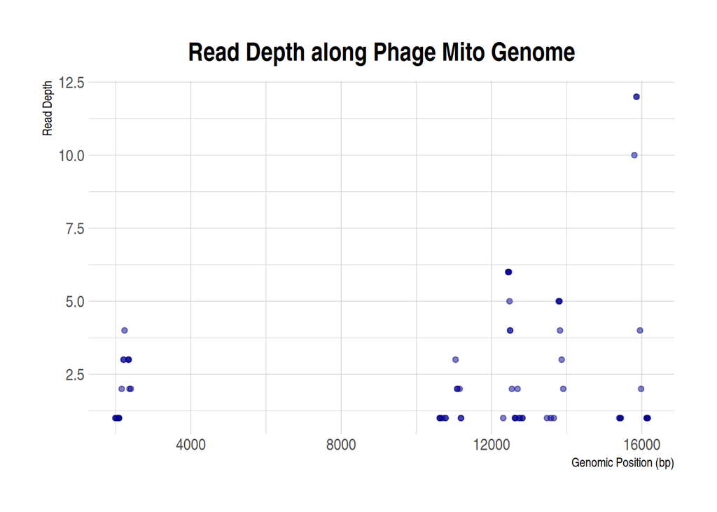

```r
lambda_coverage_plot <- ggplot(lambda_covarage, aes(x = start, y = read_depth)) +
  geom_point(alpha = 0.5, color = "darkblue") +
  labs(title = "Read Depth along Phage Lambda Umethylated control",
       x = "Genomic Position (bp)",
       y = "Read Depth") +
  theme_ipsum() +
  theme(plot.title = element_text(hjust = 0.5, face = "bold"),
        axis.title = element_text(face = "bold"))


# puc19 methylated control
puc19_coverage_plot <- ggplot(puc19_covarage, aes(x = start, y = read_depth)) +
  geom_point(alpha = 0.5, color = "darkblue") +
  labs(title = "Read Depth along Phage Puc19 Methylated control",
       x = "Genomic Position (bp)", y = "Read Depth") +
  theme_ipsum() +
  theme(plot.title = element_text(hjust = 0.5, face = "bold"),
    axis.title = element_text(face = "bold"))

# Mito genome
mito_coverage_plot <- ggplot(mito_covarage, aes(x = start, y = read_depth)) +
  geom_point(alpha = 0.5, color = "darkblue") +
  labs(title = "Read Depth along Phage Mito Genome",
       x = "Genomic Position (bp)", y = "Read Depth") +
  theme_ipsum() +
  theme(plot.title = element_text(hjust = 0.5, face = "bold"),
        axis.title = element_text(face = "bold"))
# Save the plot
ggsave( plot = mito_coverage_plot, "~/methylation/Methyl47625/figures/mito_coverage_plot.png", width = 10, height = 6, dpi = 300)
ggsave( plot = puc19_coverage_plot, "~/methylation/Methyl47625/figures/puc19_coverage_plot.png", width = 10, height = 6, dpi = 300)
ggsave( plot = lambda_coverage_plot, "~/methylation/Methyl47625/figures/lambda_coverage_plot.png", width = 10, height = 6, dpi = 300)

mito_coverage_plot
```

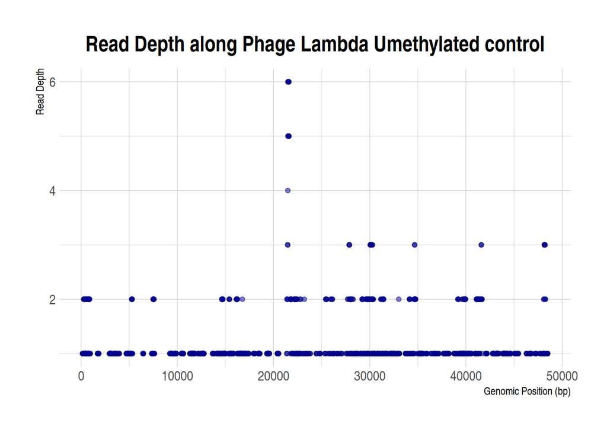

```r
lambda_coverage_plot
```

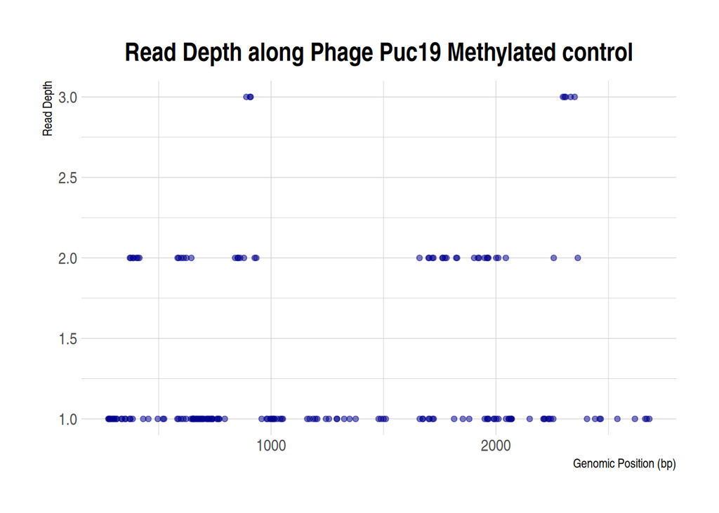

```r
puc19_coverage_plot
```

# Overall average methylation percentage (weighted by methylated and unmethylated controlgenome size)

```r
# Load necessary libraries
library(readr)
library(dplyr)

# Function to calculate weighted average methylation
calculate_weighted_methylation <- function(file_path, genome_size) {
  # Check if the file exists and is not empty
  if (!file.exists(file_path) || file.size(file_path) == 0) {
    message(paste("File not found or is empty:", file_path))
    # Return an empty tibble with the correct columns to prevent the bind_rows() error
    return(tibble(
      control = basename(file_path),
      genome_size = genome_size,
      total_methylated_reads = 0,
      total_unmethylated_reads = 0,
      average_methylation_percent = 0
    ))
  }

  # Read the methylation data file
  methylation_data <- read_tsv(file_path, col_types = cols())

  # Check if the required columns exist
  required_cols <- c("methylated_reads", "unmethylated_reads")
  if (!all(required_cols %in% colnames(methylation_data))) {
    message(paste("Required columns not found in file:", file_path))
    return(tibble(
      control = basename(file_path),
      genome_size = genome_size,
      total_methylated_reads = 0,
      total_unmethylated_reads = 0,
      average_methylation_percent = 0
    ))
  }

  # Calculate the total number of methylated and unmethylated reads
  total_methylated_reads <- sum(methylation_data$methylated_reads)
  total_unmethylated_reads <- sum(methylation_data$unmethylated_reads)
  total_reads <- total_methylated_reads + total_unmethylated_reads

  # Calculate the average methylation
  average_methylation_percent <- 0
  if (total_reads > 0) {
    average_methylation_percent <- (total_methylated_reads / total_reads) * 100
  }

  # Return the data in a tibble
  return(tibble(
    control = basename(file_path),
    genome_size = genome_size,
    total_methylated_reads = total_methylated_reads,
    total_unmethylated_reads = total_unmethylated_reads,
    average_methylation_percent = average_methylation_percent
  ))
}

# Define file paths and genome sizes for the controls
puc19_file <- "~/methylation/Methyl47625/tables/CpG_plasmid_puc19c.txt"
lambda_phage_file <- "~/methylation/Methyl47625/tables/CpG_phage_lambda.txt"
puc19_size <-  2686
lambda_phage_size <- 48502

# Calculate methylation for each control
puc19_methylation <- calculate_weighted_methylation(puc19_file, puc19_size)
lambda_phage_methylation <- calculate_weighted_methylation(lambda_phage_file, lambda_phage_size)

# Combine the results into a single data frame
combined_data <- bind_rows(puc19_methylation, lambda_phage_methylation)

# Calculate the overall average methylation, weighted by genome size
if (sum(combined_data$genome_size) > 0) {
  combined_data <- combined_data %>%
    mutate(weight = genome_size / sum(genome_size))
  overall_weighted_average <- sum(combined_data$average_methylation_percent * combined_data$weight)
} else {
  overall_weighted_average <- 0
}

# Print the final result
print(paste("Overall average methylation percentage (weighted by genome size):", overall_weighted_average))
```

```
## [1] "Overall average methylation percentage (weighted by genome size): 8.41893196596242"
```

```r
# Print individual results as a table for clarity
print(combined_data)
```

```
## # A tibble: 2 × 6
##   control              genome_size total_methylated_reads total_unmethylated_r…¹
##   <chr>                      <dbl>                  <dbl>                  <dbl>
## 1 CpG_plasmid_puc19c.…        2686                    233                      7
## 2 CpG_phage_lambda.txt       48502                     72                   1980
## # ℹ abbreviated name: ¹total_unmethylated_reads
## # ℹ 2 more variables: average_methylation_percent <dbl>, weight <dbl>
```